# VGG19 erklären: die LRP-Regeln im direkten Vergleich

## Worum geht es in diesem Notebook?

Wir nehmen ein **fertig trainiertes Bildklassifikationsnetz** (VGG19, trainiert auf ImageNet), zeigen ihm ein Katzenfoto und stellen die Frage: **„Welche Pixel haben dich zu dieser Entscheidung gebracht?"**

Die Antwort kommt als **Heatmap** — eine Karte, die jedem Eingabepixel eine Zahl zuweist: **wie stark hat dieser Pixel für (rot) oder gegen (blau) die erklärte Klasse gesprochen?** Das Verfahren dazu heißt **Layer-wise Relevance Propagation (LRP)**.

Das Besondere an diesem Notebook: Es geht **nicht** darum, eine schöne Heatmap zu produzieren. Es geht darum zu zeigen, dass es **die eine richtige Heatmap nicht gibt**. LRP ist keine einzelne Formel, sondern eine **Familie von Regeln**. Dasselbe Modell, dasselbe Bild, dieselbe Klasse — aber fünf verschiedene Regelsätze liefern fünf völlig verschieden aussehende Bilder, von unbrauchbarem Rauschen bis zu einer messerscharfen Konturkarte.

Zusätzlich ist das Notebook ein **Validierungs-Test**: Jede eigene Heatmap wird gegen eine vorberechnete Referenz aus [**iNNvestigate**](https://github.com/albermax/innvestigate) gestellt, der etablierten LRP-Bibliothek für Keras/TensorFlow. Die Referenzen liegen als `.npy`-Dateien in `tests/data/`. Sehen beide Bilder gleich aus, ist die Implementierung in diesem Repository korrekt.

## Der größere Kontext: warum überhaupt XAI?

Ein neuronales Netz lernt seine Regeln aus Daten und versteckt sie in Millionen von Gewichten. Der Kernsatz der XAI-Community lautet:

> *„Just because a model is right doesn't mean it got there for the right reason."*

Ein Netz könnte eine Katze auch am typischen Sofa im Hintergrund erkennen, an einem Wasserzeichen oder an der Bildkomposition. Solche Fälle heißen **Clever-Hans-Prädiktoren** (nach dem „rechnenden Pferd", das in Wahrheit die Körpersprache seines Besitzers las). Erklärungsverfahren wie LRP machen genau das sichtbar — und sind damit die Voraussetzung dafür, ein Modell in einem Bereich einzusetzen, in dem Fehler Konsequenzen haben (Medizin, Kreditvergabe, autonomes Fahren).

## Warum VGG19 und ein Katzenbild?

Das ist das „Hello World" der XAI. Der Aufbau hat drei Vorteile:

1. **Wir kennen die Antwort.** Auf dem Bild ist eine Katze. Zeigt die Heatmap auf den Hintergrund, ist etwas faul — entweder am Modell oder an unserer Erklärung.
2. **1000 Klassen zum Vergleich.** Man kann dasselbe Bild aus Sicht der Klasse „Katze" *und* aus Sicht der Klasse „Hund" erklären lassen (Abschnitt 10).
3. **VGG19 ist maximal einfach gebaut.** Nur Faltung, ReLU und Max-Pooling — keine Skip-Connections, keine Batch-Normalisierung. Genau die Architektur, für die die LRP-Regeln ursprünglich formuliert wurden.

## LRP in drei Sätzen

1. **Observe** — ein normaler Vorwärtsdurchlauf liefert die Vorhersage und merkt sich, wie stark jedes Neuron aktiviert war.
2. **Redistribute** — der Ausgabewert der Zielklasse wird Schicht für Schicht **rückwärts** verteilt, jeweils proportional dazu, wie stark ein Neuron zur Aktivierung des nachfolgenden beigetragen hat.
3. **Reveal** — am Ende liegt die gesamte „Relevanz" auf den Eingabepixeln und ergibt die Heatmap.

Die zentrale Eigenschaft ist die **Erhaltung (Conservation)**: LRP erzeugt und vernichtet keine Relevanz, es verteilt sie nur um.

$$\sum_j R_j \;=\; \sum_k R_k \qquad \text{für jede Schicht}$$

Wichtig zu verinnerlichen: **Relevanz ist nicht dasselbe wie Aktivierung.** Ein schwach aktiviertes Neuron kann sehr relevant sein, wenn genau es den Ausschlag gab.

## Ablauf dieses Notebooks

```
                         ┌─ Teil A: Regelvergleich am Referenzbild ─────────────┐
  Katzenfoto ──► [VGG19] ──► Logit "tabby" ──► [LRP rückwärts] ──► Heatmap
                         │        │                                            │
                         │        └── 5× mit unterschiedlichen Regeln:          │
                         │            LRP-0 → LRP-ε → α1β0 → α2β1 → Composite   │
                         │                    ↕ jeweils Vergleich mit iNNvestigate
                         └─────────────────────────────────────────────────────┘

                         ┌─ Teil B: Klassenspezifität ──────────────────────────┐
  4 Fotos (Fisch, Hund, Katze, Vogel) × 4 Zielklassen  ──►  4×4-Heatmap-Matrix
                         └─────────────────────────────────────────────────────┘
```

## Inhaltsverzeichnis

| # | Abschnitt | Inhalt |
| --- | --- | --- |
| 1 | Setup, Modell und Testbild | VGG19 laden, Preprocessing verstehen |
| 2 | Was sieht VGG19? | Vorhersage und Klassenindex 281 |
| 3 | LRP-0: die nackte z-Regel | Theorie, erste Heatmap, warum sie rauscht |
| 4 | LRP-ε: Rauschen dämpfen | ε = 0.25 als Stabilisator |
| 5 | LRP-αβ mit α=1, β=0 | nur positive Evidenz — und ein Plot-Bug |
| 6 | LRP-αβ mit α=2, β=1 | negative Evidenz und das Outlier-Problem |
| 7 | Composite-Strategie: das beste Ergebnis | pro Schicht eine eigene Regel |
| 8 | Eigene Bilder laden | vier Fotos aus dem Netz |
| 9 | Vorhersagen für die vier Bilder | wie sicher ist das Netz? |
| 10 | Klassenspezifität: die 4×4-Matrix | dasselbe Bild, vier Zielklassen |
| 11 | Fazit und Fallstricke | was man mitnehmen sollte |

**Hintergrunddokument im Repo:** `doc/LRP_Fraunhofer_HHI_Video_Zusammenfassung.md` — die LRP-Theorie in Worten, inklusive der Rot/Blau-Semantik.

## 1. Setup, Modell und Testbild

↑ Inhaltsverzeichnis

### Was passiert hier?

Vier Dinge in einer Zelle:

1. **Repository finden.** `find_repo_root()` läuft vom aktuellen Arbeitsverzeichnis nach oben, bis es `pyproject.toml` oder den Ordner `explainability/` sieht, und hängt das Ergebnis an `sys.path`. Erst dadurch ist `from explainability import LRP` importierbar, egal aus welchem Ordner der Kernel gestartet wurde.
2. **VGG19 laden.** `VGG19(weights='imagenet')` lädt die Architektur *und* die trainierten Gewichte (beim ersten Aufruf ~550 MB Download nach `~/.keras/models/`). Das Netz hat 143,7 Mio. Parameter und 26 Keras-Schichten.
3. **Zwei Varianten desselben Katzenbildes laden.** `original_cat.npy` ist das Foto zum Anschauen (`uint8`, Werte 1–233), `preprocessed_cat.npy` ist dasselbe Bild in der Form, die das Netz erwartet (`float64`, Werte −118,16 bis +110,22).
4. **Nichts weiter berechnen** — die Zelle erzeugt keine Ausgabe außer den TensorFlow-Meldungen über gefundene GPUs.

### Warum zwei Bildvarianten? Das Preprocessing

`preprocess_input` von VGG19 arbeitet im **Caffe-Modus** (so wurde das Netz 2014 trainiert) und macht zwei Dinge:

1. Kanalreihenfolge von RGB nach **BGR** drehen,
2. den **Trainingsmittelwert** pro Kanal abziehen:

$$X_{\text{BGR}} \;\leftarrow\; X_{\text{BGR}} - \begin{pmatrix} 103{,}939 \\ 116{,}779 \\ 123{,}680 \end{pmatrix}$$

Es wird **nicht** auf $[0,1]$ skaliert. Deshalb liegen die Werte grob zwischen −124 und +152. Das ist für LRP wichtig: die Eingabe hat **negative Werte**, und einige Regeln (insbesondere αβ) behandeln positive und negative Aktivierungen unterschiedlich.

### Der Aufbau von VGG19

| Index | Schicht | Ausgabeform | Rolle |
| --- | --- | --- | --- |
| 0 | `input_layer` | (224, 224, 3) | Eingabe |
| 1–2 | `block1_conv1/2` | (224, 224, 64) | Kanten, Farbübergänge |
| 3 | `block1_pool` | (112, 112, 64) | Auflösung halbieren |
| 4–5 | `block2_conv1/2` | (112, 112, 128) | Texturen |
| 6 | `block2_pool` | (56, 56, 128) |  |
| 7–10 | `block3_conv1…4` | (56, 56, 256) | Muster, Teilformen |
| 11 | `block3_pool` | (28, 28, 256) |  |
| 12–15 | `block4_conv1…4` | (28, 28, 512) | Objektteile (Augen, Ohren) |
| 16 | `block4_pool` | (14, 14, 512) |  |
| 17–20 | `block5_conv1…4` | (14, 14, 512) | ganze Objektkonzepte |
| 21 | `block5_pool` | (7, 7, 512) |  |
| 22 | `flatten` | (25088,) | 3D-Gitter → Vektor |
| 23–24 | `fc1`, `fc2` | (4096,) | Klassifikator |
| 25 | `predictions` | (1000,) | ein Wert je ImageNet-Klasse |

Insgesamt **16 Faltungs- und 3 Dense-Schichten** — daher der Name „VGG-19". Diese 19 Schichten sind genau die, für die LRP eine Regel braucht (Abschnitt 7). Die 5 Pooling-Schichten und die ReLUs bekommen eigene, einfachere Regeln.

### Einordnung

`len(model.layers) - 1 = 25` ist also die Schicht `predictions`. Alle LRP-Aufrufe in diesem Notebook erklären folglich den **Ausgabe-Score vor der Softmax** (das sogenannte *Logit*) — `LRP` entfernt die Softmax-Aktivierung intern selbst. Das ist Absicht: die Softmax ist eine Normalisierung über alle 1000 Klassen, ihr Gradient vermischt Klassen und macht Erklärungen unschärfer.

```python
import sys
from pathlib import Path


def find_repo_root() -> Path:
    p = Path.cwd().resolve()
    for candidate in [p, *p.parents]:
        if (candidate / "pyproject.toml").exists() or (candidate / "explainability").is_dir():
            return candidate
    return p


repo_root = find_repo_root()
if str(repo_root) not in sys.path:
    sys.path.insert(0, str(repo_root))

import matplotlib.pyplot as plt
import numpy as np

from tensorflow.keras.applications import VGG19
from tensorflow.keras.applications.vgg19 import preprocess_input, decode_predictions
from skimage.io import imread
from skimage.transform import resize
from explainability import LRP, LRPStrategy

data = repo_root / "tests" / "data"
model = VGG19(weights='imagenet')

image = np.load(data / "preprocessed_cat.npy")
original_image = np.load(data / "original_cat.npy")
```

[output not shown]

[output not shown]

[output not shown]

## 2. Was sieht VGG19 auf dem Bild?

↑ Inhaltsverzeichnis

### Was passiert hier?

`np.expand_dims(image, 0)` macht aus dem Bild der Form `(224, 224, 3)` einen **Batch** der Form `(1, 224, 224, 3)` — Keras erwartet immer eine Batch-Dimension. `model.predict` liefert dann 1000 Wahrscheinlichkeiten (nach Softmax), und `decode_predictions(..., 5)` übersetzt die fünf höchsten in lesbare Namen.

### Ausgabe

```
[('n02123045', 'tabby',        0.399),
 ('n02123159', 'tiger_cat',    0.335),
 ('n02124075', 'Egyptian_cat', 0.154),
 ('n02127052', 'lynx',         0.006),
 ('n02971356', 'carton',       0.004)]
```

Die Kürzel wie `n02123045` sind **WordNet-IDs**, die eindeutigen Bezeichner der ImageNet-Klassen.

### Interpretation

**Die Top-3 sind alle Katzen.** Das Netz ist sich absolut sicher, *dass* es eine Katze sieht (0,399 + 0,335 + 0,154 = 88,8 %), aber unsicher, *welche Rasse*. Das ist typisch für **feingranulare Klassen**: ImageNet enthält allein rund ein Dutzend Katzenklassen, deren Unterschiede (Fellmuster, Kopfform) selbst für Menschen schwer sind. Die 0,399 sind also **kein Zeichen von Schwäche**, sondern ein korrekt kalibrierter Ausdruck der Zweideutigkeit.

**`carton` (Pappkarton) auf Platz 5** ist der interessanteste Eintrag: Das Netz hat im Bildhintergrund etwas gefunden, das es an einen Karton erinnert. Genau solchen Hintergrund-Einfluss wollen wir mit LRP sichtbar machen.

### Warum im Folgenden `idx=281`?

281 ist der ImageNet-Index von `tabby` — die Top-1-Klasse. LRP braucht immer **eine** Zielklasse: die Frage lautet nicht „warum diese Vorhersage", sondern immer „was sprach für und gegen **genau diese Klasse**". Man kann jede der 1000 Klassen erklären, auch eine, die das Netz gar nicht gewählt hat (das nutzen wir in Abschnitt 10 aus).

### Einordnung

Dieser Schritt ist der **Observe**-Teil von LRP. Er ist auch die Referenz für alles Weitere: eine Heatmap ist nur so viel wert wie die Vorhersage, die sie erklärt. Eine Erklärung für eine falsche oder unsichere Vorhersage zu interpretieren, ist einer der häufigsten Anfängerfehler.

```python
predictions = model.predict(np.expand_dims(image, 0))
print(f'Predictions: {decode_predictions(predictions, 5)}')
```

[output not shown]

```
1/1 ━━━━━━━━━━━━━━━━━━━━ 0s 4s/step
```

```
1/1 ━━━━━━━━━━━━━━━━━━━━ 4s 4s/step
```

```
Predictions: [[('n02123045', 'tabby', np.float32(0.3994877)), ('n02123159', 'tiger_cat', np.float32(0.3351161)), ('n02124075', 'Egyptian_cat', np.float32(0.15406367)), ('n02127052', 'lynx', np.float32(0.0062551685)), ('n02971356', 'carton', np.float32(0.0035799874))]]
```

[output not shown]

## 3. LRP-0: die nackte z-Regel

↑ Inhaltsverzeichnis

### 3.1 Die Mathematik dahinter

Jedes Neuron $k$ einer Schicht berechnet im Vorwärtspass

$$z_k \;=\; \sum_j a_j \, w_{jk} \;+\; b_k$$

wobei $a_j$ die Aktivierungen der Vorgängerschicht sind. LRP dreht das um: Wenn Neuron $k$ die Relevanz $R_k$ zugewiesen bekommen hat, gibt es sie an seine Vorgänger $j$ weiter — und zwar **proportional zu deren Beitrag** $a_j w_{jk}$:

$$R_j \;=\; \sum_k \frac{a_j\,w_{jk}}{\sum_{j'} a_{j'} w_{j'k}} \; R_k$$

Das ist die **z-Regel**, auch **LRP-0** genannt. Der Bruch summiert sich über $j$ zu 1, deshalb gilt die Erhaltung $\sum_j R_j = \sum_k R_k$. Das Vorzeichen entsteht ganz natürlich: Ist $a_j w_{jk} < 0$, hat der Pixel der Aktivierung **entgegengewirkt** und bekommt negative Relevanz → **blau**.

### 3.2 Wie die Regel im Code aussieht

Naiv würde man diese Doppelsumme explizit ausrechnen — bei 25088 × 4096 Verbindungen ist das unmöglich. Der Trick (Montavon et al.) ist eine Umformung in **vier Schritte**, die alle mit den vorhandenen Faltungs-Operationen erledigt werden können. So steht es wörtlich in `explainability/layers/layer.py`:

| Schritt | Formel | Code |
| --- | --- | --- |
| 1. forward | $z_k = \sum_j a_j w_{jk}$ | `z = self.forward(a, w)` |
| 2. divide | $s_k = R_k / z_k$ | `s = R / z` |
| 3. backward | $c_j = \sum_k w_{jk} s_k$ | `c = self.backward(w, s)` |
| 4. multiply | $R_j = a_j \, c_j$ | `R = tf.multiply(a, c)` |

Schritt 3 ist eine **transponierte Faltung** — genau die Operation, die auch beim normalen Backpropagation-Gradienten benutzt wird. LRP ist deshalb rechnerisch etwa so teuer wie ein Trainingsschritt.

Zwei Details der Implementierung, die man kennen sollte:

- **Bias.** `z` enthält den Bias *nicht*. Vorher korrigiert der Code mit `R = (R * z) / (z + bias)` die eingehende Relevanz um den Anteil, den der Bias am Pre-Aktivierungswert hat. Dieser Anteil **verschwindet** — Bias-Terme „schlucken" Relevanz, die Erhaltung gilt also nur bis auf die Bias-Beiträge.
- **Max-Pooling.** Ohne weitere Angabe nutzt `MaxPoolingLRP` die Strategie *winner-takes-all*: die gesamte Relevanz eines 2×2-Fensters geht an das Pixel, das im Vorwärtspass das Maximum geliefert hat. Bei fünf Pooling-Stufen wird die Relevanz also wiederholt auf einzelne Pixel zusammengezogen.

### 3.3 Was diese Zelle konkret tut

```
lrp = LRP(model, layer=len(model.layers) - 1, idx=281, epsilon=1e-15)
```

| Argument | Bedeutung |
| --- | --- |
| `model` | das zu erklärende (trainierte) Netz |
| `layer=25` | ab welcher Schicht rückwärts erklärt wird → `predictions` |
| `idx=281` | welches Ausgabeneuron erklärt wird → `tabby` |
| `epsilon=1e-15` | Regel-Parameter, hier nur als Schutz gegen Division durch 0 |

`LRP` ist selbst ein **Keras-Modell**. Es wird gebaut, indem der Graph des Originalnetzes topologisch sortiert, umgedreht und jede Schicht durch ihre LRP-Gegenstück-Schicht ersetzt wird. Der Aufruf `lrp(...)` ist dann ein normaler Forward-Pass durch dieses Erklärer-Netz.

Die Initialisierung der Relevanz geschieht per Maske:

$$R_k^{(\text{letzte Schicht})} \;=\; \begin{cases} z_{281} & k = 281 \\ 0 & \text{sonst}\end{cases}$$

Danach drei Nachbearbeitungsschritte:

1. `explanations` hat die Form `(1, 224, 224, 3)` — ein Relevanzwert **pro Farbkanal**. Die Summe über die Kanäle macht daraus eine 2D-Karte: $$H_{xy} = \sum_{c \in \{B,G,R\}} R_{xyc}$$
2. Normalisierung auf den Bereich $[-1, 1]$: $\tilde H = H / \max_{xy} |H_{xy}|$
3. Anzeige mit `cmap='seismic'` und `clim=(-1, 1)`. Die Farbskala *seismic* läuft **blau → weiß → rot**, `clim` fixiert sie so, dass **weiß immer genau 0** bedeutet. Ohne dieses `clim` würde matplotlib automatisch skalieren und die Null wäre nicht mehr weiß — die Heatmap wäre unlesbar.

Parallel wird `cat_explanations_none.npy` geladen und identisch behandelt: die iNNvestigate-Referenz für dieselbe Regel.

### 3.4 Was man auf der Abbildung sieht

**Beide Bilder sind praktisch identisch.** Das ist die eigentliche Botschaft dieser Zelle: die Implementierung in diesem Repository reproduziert iNNvestigate. Ein solcher Vergleich gegen eine Referenzimplementierung ist unverzichtbar, denn ein XAI-Verfahren liefert **immer** ein buntes Bild — auch wenn ein Tensor vertauscht oder eine Regel falsch angewandt ist. Das sieht man einem Bild nicht an.

**Das Bild ist unbrauchbar rauschig.** Ein dichtes Salz-und-Pfeffer-Muster aus roten und blauen Einzelpixeln, ohne erkennbare Struktur. Die Katze ist nur als sehr blasser Umriss zu erahnen.

**Die stärkste Aktivität liegt im linken Bilddrittel** — also im dunklen, texturierten Hintergrund (Türrahmen), **nicht** auf der Katze. Wer dieses Bild ohne Vorwissen interpretieren müsste, käme zum Schluss „das Netz schaut auf den Hintergrund". Das wäre **falsch** — es ist ein Artefakt der Regel, nicht eine Eigenschaft des Modells.

### 3.5 Warum rauscht LRP-0 so?

Der Nenner $\sum_{j'} a_{j'} w_{j'k}$ kann beliebig **klein** werden, wenn sich positive und negative Beiträge fast aufheben. Dann explodiert der Bruch. Bei 19 hintereinandergeschalteten Schichten multiplizieren sich diese Instabilitäten auf.

Theoretisch ist LRP-0 zudem nichts Neues: für ReLU-Netze ohne Bias ist es **identisch zu $\text{Gradient} \times \text{Input}$**. Und dass reine Gradienten-Saliency verrauscht ist, ist seit Jahren bekannt — ein Gradient beschreibt nur eine *infinitesimale* Umgebung des Eingabepunkts, nicht die eigentliche Entscheidung.

### Einordnung

LRP-0 ist der Ausgangspunkt, nicht das Ziel. Die folgenden vier Abschnitte zeigen, wie man von hier zu einer brauchbaren Erklärung kommt — durch immer geschicktere Regeln. Wichtig für den Kopf: **Alle fünf Bilder sind „korrekt"** in dem Sinne, dass sie ihre jeweilige Regel exakt umsetzen. Es gibt keine objektiv wahre Heatmap; es gibt nur Regeln mit unterschiedlichen Eigenschaften.

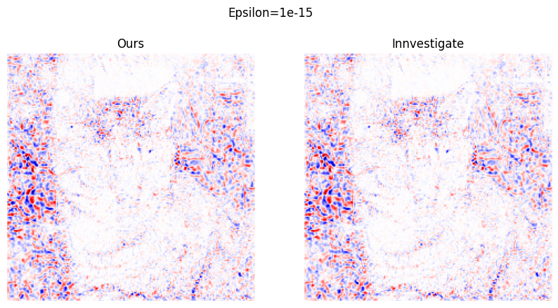

```python
lrp = LRP(model, layer=len(model.layers) - 1, idx=281, epsilon=1e-15)
explanations = lrp(np.expand_dims(image, 0))
explanations = np.sum(explanations, axis=-1)
explanations = explanations / np.amax(np.abs(explanations))

innvestigate = np.load(data / 'cat_explanations_none.npy')
innvestigate = np.sum(innvestigate, axis=-1)
innvestigate = innvestigate / np.amax(np.abs(innvestigate))

fig, ax = plt.subplots(1, 2, figsize=(10, 5))
fig.suptitle('Epsilon=1e-15')

ax[0].imshow(explanations[0], cmap='seismic', clim=(-1, 1))
ax[0].axis('off')
ax[0].set_title('Ours')
ax[1].imshow(innvestigate, cmap='seismic', clim=(-1, 1))
ax[1].axis('off')
ax[1].set_title('Innvestigate')
plt.show()
```

## 4. LRP-ε: das Rauschen dämpfen

↑ Inhaltsverzeichnis

### Was passiert hier?

Genau derselbe Code wie in Abschnitt 3 — nur `epsilon=0.25` statt `1e-15`. Die Regel lautet jetzt:

$$R_j \;=\; \sum_k \frac{a_j\,w_{jk}}{z_k + \epsilon \cdot \mathrm{sign}(z_k)} \; R_k$$

Im Code ist das eine einzige Zeile:

```
epsilon = tf.multiply(self.epsilon, tf.math.sign(z))
z = tf.add(z, epsilon)
```

Das `sign(z)` ist wesentlich: $\epsilon$ wird **immer betragsvergrößernd** addiert, damit der Nenner nie kleiner wird und nie das Vorzeichen wechselt.

### Wie wirkt das?

$\epsilon$ ist ein **Schwellwert für Bedeutsamkeit**. Für Neuronen mit großem $|z_k|$ (starke, eindeutige Aktivierung) ist $\epsilon = 0{,}25$ irrelevant. Für Neuronen mit $|z_k| \approx 0$ — genau die Instabilitätsquelle aus Abschnitt 3.5 — dominiert $\epsilon$ den Nenner und drückt den Bruch nach 0.

$$\frac{a_j w_{jk}}{z_k \pm \epsilon} \quad\longrightarrow\quad \begin{cases} \text{unverändert} & |z_k| \gg \epsilon \\ \approx 0 & |z_k| \ll \epsilon \end{cases}$$

Der Preis: **die Erhaltung wird verletzt.** Ein Teil der Relevanz „versickert" bei jedem Schritt. Konkret nachrechenbar an den Referenzdateien: die Gesamtrelevanz sinkt von **3,724** (LRP-0) auf **3,689** (ε = 0,25), also knapp 1 % Verlust. Der `LRPLayer` hat für solche Fälle das optionale Flag `adjust_epsilon`, das die Summe hinterher wieder hochskaliert — hier wird es nicht benutzt.

### Was man auf der Abbildung sieht

**Etwas ruhiger, aber dieselbe Grundstruktur.** Vergleicht man Seite an Seite mit Abschnitt 3, sind die Extrempixel weniger stark, die weißen Flächen etwas größer, insgesamt weniger „hartes" Rot und Blau. Die Aussage des Bildes ändert sich jedoch **nicht**: das linke Bilddrittel dominiert weiterhin, die Katze bleibt kaum erkennbar.

**Wieder stimmen beide Panels überein.** Zweiter erfolgreicher Validierungstest.

### Interpretation

ε = 0,25 ist zu wenig, um das Problem zu lösen. Man könnte ε drastisch erhöhen — dann verschwindet zwar das Rauschen, aber es verschwindet auch fast alle Relevanz. ε steuert also einen **Trade-off zwischen Rauschen und Signalerhalt** und kann ihn nicht auflösen. Die Lösung liegt in einer anderen Regelfamilie (Abschnitt 5) bzw. in der Kombination beider (Abschnitt 7).

### Einordnung

In der Praxis ist LRP-ε trotzdem wichtig — allerdings **nicht für das ganze Netz**, sondern gezielt für die **oberen, dichten Schichten**. Dort ist der Bedarf an Rauschunterdrückung am größten (viele Verbindungen, viel Kompensation), und der Relevanzverlust fällt weniger auf. Genau so wird ε in Abschnitt 7 eingesetzt.

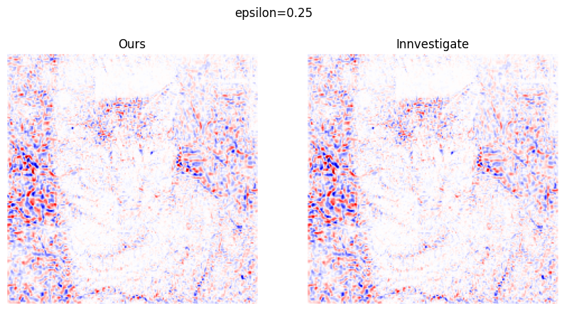

```python
lrp = LRP(model, layer=len(model.layers) - 1, idx=281, epsilon=0.25)
explanations = lrp(np.expand_dims(image, 0))
explanations = np.sum(explanations, axis=-1)
explanations = explanations / np.amax(np.abs(explanations))

innvestigate = np.load(data / 'cat_explanations_eps.npy')
innvestigate = np.sum(innvestigate, axis=-1)
innvestigate = innvestigate / np.amax(np.abs(innvestigate))

fig, ax = plt.subplots(1, 2, figsize=(10, 5))
fig.suptitle('epsilon=0.25')

ax[0].imshow(explanations[0], cmap='seismic', clim=(-1, 1))
ax[0].axis('off')
ax[0].set_title('Ours')
ax[1].imshow(innvestigate, cmap='seismic', clim=(-1, 1))
ax[1].axis('off')
ax[1].set_title('Innvestigate')
plt.show()
```

## 5. LRP-αβ mit α=1, β=0: nur positive Evidenz

↑ Inhaltsverzeichnis

### Die Idee: positive und negative Beiträge getrennt behandeln

Das Grundproblem von LRP-0/ε ist, dass sich positive und negative Beiträge im **gemeinsamen Nenner** gegenseitig auslöschen. Die **αβ-Regel** trennt sie und normiert jede Gruppe für sich:

$$R_j \;=\; \sum_k \left( \alpha \, \frac{(a_j w_{jk})^{+}}{\sum_{j'} (a_{j'} w_{j'k})^{+}} \;-\; \beta \, \frac{(a_j w_{jk})^{-}}{\sum_{j'} (a_{j'} w_{j'k})^{-}} \right) R_k$$

mit $(\cdot)^+ = \max(\cdot, 0)$ und $(\cdot)^- = \min(\cdot, 0)$. Weil jeder der beiden Nenner nur gleichsinnige Terme enthält, kann keiner mehr durch Auslöschung nahe Null geraten — die **Instabilität ist strukturell beseitigt**, ohne Regularisierungsparameter.

Damit die Erhaltung erhalten bleibt, muss gelten:

$$\alpha - \beta = 1$$

Das erzwingt der Code als Assertion (`explainability/layers/layer.py`):

```
if alpha is not None:
    assert alpha == beta + 1, 'beta must be equal to alpha + 1'
```

Es gibt also nur **einen** freien Parameter. Gängige Wahlen: (α=1, β=0), (α=2, β=1), (α=1,5, β=0,5).

### Was passiert bei α=1, β=0?

Der zweite Term fällt komplett weg. Es wird **ausschließlich positive Evidenz** verteilt:

$$R_j \;=\; \sum_k \frac{(a_j w_{jk})^{+}}{\sum_{j'} (a_{j'} w_{j'k})^{+}} \; R_k$$

Die Heatmap kann damit **keine negativen Werte** enthalten. Das ist an der Referenzdatei nachprüfbar: `cat_explanations_a1b0.npy` hat als Minimum $+3{,}5 \cdot 10^{-6}$, also ausschließlich positive Werte. Die Frage, die das Bild beantwortet, ist folglich nicht mehr „was sprach für und gegen Tabby", sondern nur noch: **„woraus baut sich die Tabby-Evidenz auf?"**

### Was man auf der Abbildung sieht — linkes Panel („Ours")

**Ein völlig anderes Bild als in Abschnitt 3/4.** Aus dem Rauschteppich ist eine saubere, lesbare Karte geworden:

- **Die Augen sind die klarsten Hotspots** — konzentrische rote Ringe um beide Pupillen.
- **Die Ohrkonturen** treten als scharfe rote Linien hervor, ebenso die **Nase** und die **Schnurrhaar-Wurzeln**.
- **Das gepunktete Fellmuster** auf Brust und Flanke ist als feine rote Textur erkennbar — plausibel, denn „tabby" ist definitionsgemäß eine **Fellzeichnung**.
- **Der Hintergrund ist fast vollständig weiß**, das linke Bilddrittel, das LRP-0 dominierte, spielt praktisch keine Rolle mehr.
- **Alles ist rot**, kein einziger blauer Bereich — wie oben hergeleitet.

Das ist die klassische Lehrbuch-Heatmap aus dem Original-Paper von [Bach et al. (2015)](https://doi.org/10.1371/journal.pone.0130140): das Modell schaut auf die Katze, und dort auf genau die Merkmale, die ein Mensch auch nennen würde. Das Netz liegt also aus den richtigen Gründen richtig.

### Das rechte Panel ist leer — warum?

Das ist **kein Fehler des Verfahrens, sondern ein Plot-Bug in dieser Zelle**. In allen anderen vier Blöcken folgt auf `np.sum(...)` eine Normalisierungszeile:

```
innvestigate = innvestigate / np.amax(np.abs(innvestigate))
```

In diesem Block **fehlt genau diese Zeile**. Die Referenzwerte haben ein Maximum von $3{,}72 \cdot 10^{-3}$, werden aber mit `clim=(-1, 1)` dargestellt. Alle Werte landen damit im Intervall $[0;\,0{,}004]$ der Farbskala — also praktisch exakt auf Weiß. Die Daten sind da, nur unsichtbar.

**Lehre daraus:** Absolute Relevanzwerte sind zwischen Regeln nicht vergleichbar. Ohne Normalisierung ist eine LRP-Heatmap nicht interpretierbar, und ein leeres Panel bedeutet nicht „keine Relevanz", sondern meistens „falsche Skala".

### Einordnung

αβ mit β=0 ist die freundlichste Regel für Präsentationen: stabil, aufgeräumt, gut lesbar. Sie hat aber einen konzeptionellen Preis. Indem sie negative Evidenz komplett verwirft, kann sie **nicht mehr zeigen, was gegen eine Klasse spricht** — und damit auch nicht erklären, warum eine konkurrierende Klasse verloren hat. Für die Fehleranalyse eines Modells („warum hat es *nicht* Klasse X gewählt?") ist sie deshalb ungeeignet. Genau darum geht es im nächsten Abschnitt.

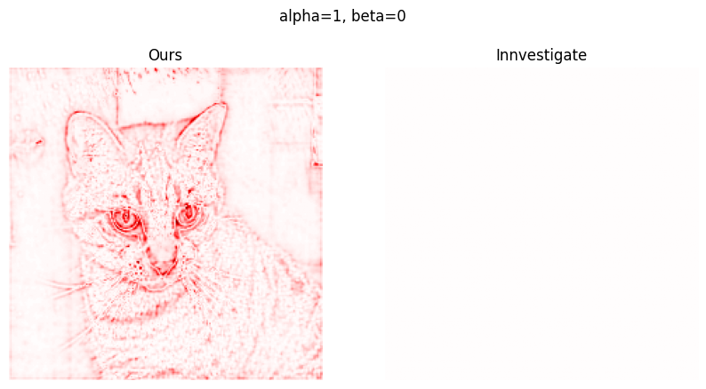

```python
lrp = LRP(model, layer=len(model.layers) - 1, idx=281, alpha=1, beta=0)
explanations = lrp(np.expand_dims(image, 0))
explanations = np.sum(explanations, axis=-1)
explanations = explanations / np.amax(np.abs(explanations))

innvestigate = np.load(data / 'cat_explanations_a1b0.npy')
innvestigate = np.sum(innvestigate, axis=-1)

fig, ax = plt.subplots(1, 2, figsize=(10, 5))
fig.suptitle('alpha=1, beta=0')

ax[0].imshow(explanations[0], cmap='seismic', clim=(-1, 1))
ax[0].axis('off')
ax[0].set_title('Ours')
ax[1].imshow(innvestigate, cmap='seismic', clim=(-1, 1))
ax[1].axis('off')
ax[1].set_title('Innvestigate')
plt.show()
```

## 6. LRP-αβ mit α=2, β=1: negative Evidenz zulassen

↑ Inhaltsverzeichnis

### Was passiert hier?

Dieselbe αβ-Regel, aber jetzt mit β = 1. Die Nebenbedingung α − β = 1 ist mit α = 2 erfüllt. Beide Terme sind aktiv:

$$R_j \;=\; \sum_k \left( 2 \cdot \frac{(a_j w_{jk})^{+}}{\sum (a w)^{+}} \;-\; 1 \cdot \frac{(a_j w_{jk})^{-}}{\sum (a w)^{-}} \right) R_k$$

Interpretation der Parameter: **α ist die Verstärkung der „Pro"-Evidenz, β die der „Contra"-Evidenz.** Bei (2, 1) wird doppelt so viel positive Relevanz verteilt wie bei (1, 0), davon aber eine Einheit negativer Relevanz wieder abgezogen. Netto bleibt dieselbe Summe (α − β = 1), aber die **Kontraste werden größer**: das Bild wird „kontrastreicher" bzw. „aggressiver".

So sieht die Zerlegung im Code für Faltungsschichten aus (`explainability/layers/conv.py`) — sie zerlegt sowohl die Aktivierung als auch das Gewicht in Positiv- und Negativteil und kombiniert vier Faltungen:

```
zpos = forward(a⁺, w⁺) + forward(a⁻, w⁻)   # alle positiven Produkte
zneg = forward(a⁺, w⁻) + forward(a⁻, w⁺)   # alle negativen Produkte
```

Dass hier **beide** Vorzeichen von $a$ berücksichtigt werden, ist bei VGG19 relevant: nach dem Caffe-Preprocessing ist die Eingabe teils negativ (Abschnitt 1).

### Was man auf der Abbildung sieht — linkes Panel („Ours")

**Ähnlich strukturiert wie α1β0, aber schwächer und mit Blau.** Die Konturen von Ohren, Kopf und Nase sind weiterhin die dominanten roten Linien. Neu sind zwei Dinge:

- **Blaue Kerne in den Augen und an den Ohrspitzen.** Genau die Stellen, die bei α1β0 die stärksten roten Hotspots waren, haben jetzt einen negativen Anteil. Das ist kein Widerspruch: dieselbe Bildstelle liefert gleichzeitig starke Pro- und starke Contra-Beiträge, und β = 1 macht letztere sichtbar. Inhaltlich plausibel — die Augen sind *das* Merkmal, an dem sich die konkurrierenden Katzenklassen (`tiger_cat`, `Egyptian_cat`) unterscheiden, sie drücken also gleichzeitig von `tabby` weg.
- **Insgesamt blasser.** Die Fellzeichnung ist nur noch angedeutet.

### Warum ist das rechte Panel wieder fast leer?

Diesmal **ist** die Normalisierungszeile vorhanden — die Erklärung ist eine andere und lehrreichere: **drei Ausreißer-Pixel**.

Nachgerechnet an `cat_explanations_a2b1.npy` (nach Kanalsumme):

| Größe | Wert |
| --- | --- |
| Maximum | +10,64 |
| Minimum | −0,84 |
| 99,9-Perzentil nach Normalisierung | 0,0094 |
| 99-Perzentil nach Normalisierung | 0,0031 |
| Median nach Normalisierung | 0,00004 |
| Pixel mit \|Wert\| > 0,1 nach Normalisierung | **3 von 50 176** |

Die Normalisierung $\tilde H = H / \max|H|$ teilt also durch einen Wert, der von drei Einzelpixeln bestimmt wird und **12-mal größer** ist als der stärkste negative Wert. Alle echten Bildstrukturen werden dadurch auf unter 1 % der Farbskala gestaucht.

### Einordnung — ein sehr praktischer Fallstrick

Dieses Panel ist das beste Beispiel für einen Fehler, den fast jeder einmal macht: **Max-Normalisierung ist gegenüber Ausreißern nicht robust.** In der Praxis normalisiert man deshalb auf ein **Perzentil** statt auf das Maximum, z. B.

$$\tilde H \;=\; \mathrm{clip}\!\left(\frac{H}{q_{99{,}5}(|H|)},\, -1,\, 1\right)$$

Warum das linke Panel dieses Problem nicht hat: die Implementierung in diesem Repository erzeugt an dieser Stelle keine so extremen Einzelwerte. Die naheliegende Ursache ist eine unterschiedliche Behandlung der **Bias-Terme in den αβ-Nennern** — nachgewiesen ist das hier nicht, aber ein Blick auf die Gesamtsummen der Referenzdateien zeigt, dass die Regeln insgesamt sehr unterschiedliche Relevanzmengen durchlassen:

| Regel | Summe aller Relevanzen |
| --- | --- |
| LRP-0 | 3,72 |
| LRP-ε (0,25) | 3,69 |
| α=1, β=0 | 8,62 |
| α=2, β=1 | 107,90 |
| Composite (Abschnitt 7) | 4,93 |

Exakte Erhaltung gilt nur für die reine z-Regel ohne Bias. Sobald Bias-Terme im Spiel sind — und VGG19 hat in jeder Schicht welche —, wird Relevanz geschluckt oder verstärkt. Für die **visuelle** Interpretation ist das folgenlos, weil ohnehin normalisiert wird. Wer aber Relevanzen **summiert oder vergleicht** (etwa pro Bildregion oder pro Hirnregion, wie im Notebook `Explain_brain_age_predictions`), muss diese Verletzung kennen.

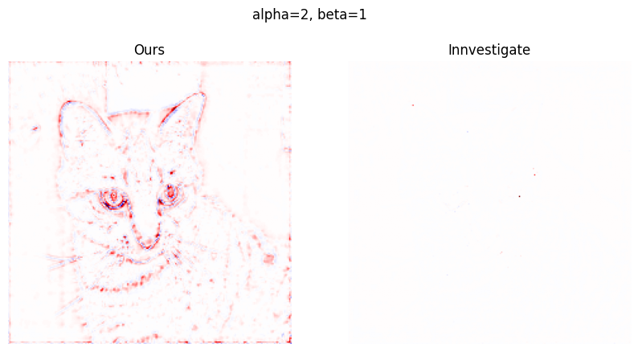

```python
lrp = LRP(model, layer=len(model.layers) - 1, idx=281, alpha=2, beta=1)
explanations = lrp(np.expand_dims(image, 0))
explanations = np.sum(explanations, axis=-1)
explanations = explanations / np.amax(np.abs(explanations))

innvestigate = np.load(data / 'cat_explanations_a2b1.npy')
innvestigate = np.sum(innvestigate, axis=-1)
innvestigate = innvestigate / np.amax(np.abs(innvestigate))

fig, ax = plt.subplots(1, 2, figsize=(10, 5))
fig.suptitle('alpha=2, beta=1')

ax[0].imshow(explanations[0], cmap='seismic', clim=(-1, 1))
ax[0].axis('off')
ax[0].set_title('Ours')
ax[1].imshow(innvestigate, cmap='seismic', clim=(-1, 1))
ax[1].axis('off')
ax[1].set_title('Innvestigate')
plt.show()
```

## 7. Composite-Strategie: für jede Schicht die passende Regel

↑ Inhaltsverzeichnis

### Die zentrale Einsicht

Bisher haben wir **eine** Regel auf **alle** 19 Schichten angewandt. Das ist aber gar nicht sinnvoll, denn die Schichten haben völlig unterschiedliche Aufgaben:

| Schichtbereich | Was dort passiert | Was die Erklärung braucht |
| --- | --- | --- |
| **oben** (`fc1`, `fc2`, `predictions`) | abstrakte Klassenentscheidung, sehr viele Verbindungen, viel gegenseitige Kompensation | **Rauschunterdrückung** → LRP-ε |
| **Mitte** (Faltungsblöcke) | Objektteile, räumliche Muster | **Stabilität und Struktur** → LRP-αβ |
| **unten** (erste Faltung) | einzelne Pixel und Farbkanäle; hier entscheidet sich die räumliche Schärfe der Heatmap | **räumliche Glättung**, unabhängig von Pixelwerten → flat-Regel |

Diese Kombination heißt **Composite-LRP** (auch *LRP-CMP*) und ist heute die empfohlene Standardanwendung — siehe [Montavon et al. (2019)](https://link.springer.com/chapter/10.1007/978-3-030-28954-6_10) und Kohlbrenner et al. (2020). Sie ist der Grund, warum die Abbildung dieses Abschnitts „Best" heißt.

### Die flat-Regel

Neu ist hier die **flat-Regel** für die erste Faltungsschicht:

$$R_j \;=\; \sum_k \frac{1}{\#\{j'\}} \; R_k$$

Die Relevanz wird **völlig gleichmäßig** auf alle Eingänge des Filterfensters verteilt, ohne jeden Bezug auf Aktivierungen oder Gewichte. Im Code ist das denkbar einfach (`explainability/layers/layer.py`):

```
if self.flat:
    a = tf.ones_like(a)
    w = tf.ones_like(w)
```

Wozu das gut ist: In der ersten Schicht wären die Relevanzen sonst direkt proportional zu den Pixelintensitäten — helle Pixel bekämen automatisch mehr Relevanz als dunkle, was inhaltlich nichts bedeutet. Die flat-Regel wirkt wie ein **lokaler Tiefpassfilter** und liefert genau die räumlich zusammenhängenden Flächen, die eine Heatmap lesbar machen (statt Einzelpixel-Rauschen).

### Wie die Strategie gelesen wird

`LRPStrategy(layers=[...])` erwartet **genau einen Eintrag pro gewichtstragender Schicht**, hier also 19 (16 Faltungen + 3 Dense). Der Code prüft das hart:

```
assert len(strategy.layers) == len(standard_lrp_layers)
```

Die Liste ist **von der Eingabe zur Ausgabe** geordnet (intern wird sie mit `[::-1]` gedreht, weil das Erklärer-Netz rückwärts aufgebaut wird). Damit ergibt sich diese Zuordnung:

| Listeneinträge | Regel | Schichten |
| --- | --- | --- |
| 1 | `flat` | `block1_conv1` |
| 2 – 15 | α = 1,5 / β = 0,5 | `block1_conv2` … `block5_conv3` (14 Faltungen) |
| 16 – 19 | ε = 0,25 | `block5_conv4`, `fc1`, `fc2`, `predictions` |

Die 5 Max-Pooling-Schichten sind nicht Teil dieser Liste; sie behalten die Voreinstellung *winner-takes-all*. Über `LRPStrategy(pooling=[...])` könnte man auch das umstellen (`redistribute` oder `flat`).

α = 1,5 / β = 0,5 ist ein Kompromiss zwischen den Abschnitten 5 und 6: negative Evidenz bleibt sichtbar, ist aber nur halb gewichtet.

### ⚠️ Eine Eigenheit dieser Zelle

```
explanations = lrp(np.expand_dims(image, 0) + np.amin(image))
```

Hier wird zum Bild **das eigene Minimum addiert**, also $-118{,}16$ — jeder Pixel wird um diesen Betrag verschoben, der Wertebereich wandert von $[-118;\,110]$ nach $[-236;\,-8]$. Das ist eine **andere Eingabe** als in allen vorigen Abschnitten und weit außerhalb dessen, was das Netz je gesehen hat. Die Zeile diente offenbar dazu, exakt die Vorverarbeitung der iNNvestigate-Referenzdatei nachzubauen.

Für die Interpretation heißt das: die gezeigte Heatmap erklärt streng genommen ein **stark abgedunkeltes** Bild, nicht das links daneben angezeigte Original. Dass das Ergebnis trotzdem überzeugend aussieht, liegt unter anderem an der flat-Regel in der ersten Schicht, die von den absoluten Pixelwerten unabhängig ist. Wer diese Strategie übernimmt, sollte den Offset weglassen — in Abschnitt 10 fehlt er auch.

### Was man auf der Abbildung sieht

Drei Panels: **Original**, **Ours**, **Innvestigate**.

**Links das Original.** Eine getigerte Katze frontal, vor einem dunklen Türrahmen mit rötlicher Fläche oben.

**Mitte und rechts sind nahezu identisch** — der überzeugendste der fünf Validierungstests, weil hier die komplizierteste Regelkombination geprüft wird.

**Die Heatmap ist scharf, zusammenhängend und anatomisch sinnvoll:**

- Die **Silhouette der Katze** ist als durchgehende rote Linie nachgezeichnet — Ohren, Kopf, Wangen, Brustkontur.
- Die **Augen** sind wieder klare rote Ringe.
- Die **Fellzeichnung** erscheint als feines rotes Punktmuster über Brust und Flanke — genau das Merkmal, das „tabby" definiert.
- Der **Hintergrund ist überwiegend weiß**, also irrelevant.
- Am **linken und rechten Bildrand** liegt ein diffuser **blauer Saum**. Das ist ein **Padding-Artefakt**: an den Bildrändern faltet das Netz über künstlich mit Nullen aufgefüllte Bereiche, und die flat-Regel verteilt dort Relevanz auf Positionen, die kein echtes Signal tragen. Solche Randstreifen sind ein bekanntes LRP-Artefakt und **kein** Hinweis darauf, dass das Modell auf den Bildrand schaut.

Der Vergleich mit Abschnitt 3 ist die Kernaussage des ganzen Notebooks: **gleiches Modell, gleiches Bild, gleiche Klasse — unbrauchbares Rauschen gegen eine publikationsreife Konturkarte.** Der Unterschied liegt ausschließlich in der Regelwahl.

### Einordnung

Damit wird auch klar, wo die Grenze der Methode liegt: Man kann eine Heatmap durch Regelwahl in erheblichem Maße gestalten. Das macht LRP nicht wertlos, verlangt aber Disziplin:

1. **Regeln vor dem Ansehen der Ergebnisse festlegen**, nicht danach die schönste auswählen.
2. **Die verwendete Strategie immer mitpublizieren** — eine Heatmap ohne Regelangabe ist nicht reproduzierbar.
3. Nicht auf das Auge verlassen, sondern **quantitativ prüfen** (Pixel-Flipping, Erhaltungssummen, Klassenspezifität wie in Abschnitt 10).

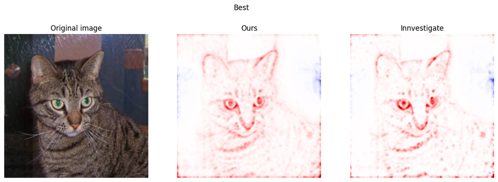

```python
alpha=1.5
beta=0.5

strategy = LRPStrategy(
    layers=[
        {'flat': True},
        {'alpha': alpha, 'beta': beta},
        {'alpha': alpha, 'beta': beta},
        {'alpha': alpha, 'beta': beta},
        {'alpha': alpha, 'beta': beta},
        {'alpha': alpha, 'beta': beta},
        {'alpha': alpha, 'beta': beta},
        {'alpha': alpha, 'beta': beta},
        {'alpha': alpha, 'beta': beta},
        {'alpha': alpha, 'beta': beta},
        {'alpha': alpha, 'beta': beta},
        {'alpha': alpha, 'beta': beta},
        {'alpha': alpha, 'beta': beta},
        {'alpha': alpha, 'beta': beta},
        {'alpha': alpha, 'beta': beta},
        {'epsilon': 0.25},
        {'epsilon': 0.25},
        {'epsilon': 0.25},
        {'epsilon': 0.25},
    ]
)

lrp = LRP(model, layer=len(model.layers) - 1, idx=281, strategy=strategy)
explanations = lrp(np.expand_dims(image, 0) + np.amin(image))
explanations = np.sum(explanations, axis=-1)
explanations = explanations / np.amax(np.abs(explanations))

innvestigate = np.load(data / 'cat_explanations_best.npy')
innvestigate = np.sum(innvestigate, axis=-1)
innvestigate = innvestigate / np.amax(np.abs(innvestigate))

fig, ax = plt.subplots(1, 3, figsize=(15, 5))
fig.suptitle('Best')

ax[0].imshow(original_image)
ax[0].axis('off')
ax[0].set_title('Original image')
ax[1].imshow(explanations[0], cmap='seismic', clim=(-1, 1))
ax[1].axis('off')
ax[1].set_title('Ours')
ax[2].imshow(innvestigate, cmap='seismic', clim=(-1, 1))
ax[2].axis('off')
ax[2].set_title('Innvestigate')
plt.show()
```

## 8. Teil B — vier eigene Bilder laden

↑ Inhaltsverzeichnis

### Was passiert hier?

Teil A war ein Methodenvergleich an einem eingefrorenen Referenzbild. Teil B stellt eine ganz andere Frage: **Ist die Erklärung überhaupt klassenspezifisch?** Dafür brauchen wir mehrere Bilder mit klar unterschiedlichen Klassen.

Die Zelle lädt vier Fotos per HTTP (Goldfisch, Border Collie, Katze, Kolibri), speichert sie nach `/tmp/` und bringt sie in Modellform:

| Schritt | Code | Zweck |
| --- | --- | --- |
| Herunterladen | `requests.get(urls[key])` | JPEG nach `/tmp/{key}.jpg` |
| Einlesen | `imread(...)` | → NumPy-Array, beliebige Größe |
| Skalieren | `resize(img, (224, 224), preserve_range=True)` | auf die Eingabegröße von VGG19 |
| Zurückcasten | `.astype(np.uint8)` | `resize` liefert float; `preprocess_input` erwartet 0–255 |
| Anzeigen | `plt.imshow(img)` | Kontrollblick, in `original_images` gemerkt |
| Vorverarbeiten | `preprocess_input(img)` | BGR + Mittelwertabzug, nach `images` |

Wichtig ist die **Doppelbuchhaltung**: `original_images[key]` ist die Version zum Anschauen, `images[key]` die Version fürs Netz. Die Reihenfolge ist entscheidend — `preprocess_input` **erst nach** dem Merken des Originals.

Zwei Hinweise zu `preserve_range=True`: ohne dieses Flag würde `skimage.resize` die Werte automatisch nach $[0,1]$ skalieren, und der anschließende Cast nach `uint8` würde alles auf 0 runden — ein komplett schwarzes Bild. Und `resize` auf ein Quadrat **verzerrt das Seitenverhältnis**; beim Fischbild (ursprünglich breiter als hoch) ist das sichtbar.

### Was man auf den vier Abbildungen sieht

| Bild | Inhalt | Besonderheit für die Erklärung |
| --- | --- | --- |
| `cat` | cremefarbenes Kätzchen, blaue Augen, vor dunkelrotem Hintergrund, auf Leopardenfell-Decke | **nicht** getigert — anders als die Referenzkatze aus Teil A |
| `dog` | Border Collie im Profil, schwarz-weiß, Wiese/Gras-Hintergrund | ganzkörperlich, viel Hintergrund |
| `bird` | Kolibri im Flug an einer roten Blütenrispe | zwei Objekte im Bild: Vogel **und** Blüten |
| `fish` | zwei Goldfische auf hellem, fast weißem Grund | quasi kein Hintergrund |

### Einordnung

Die Bildauswahl ist bewusst so getroffen, dass sie **vier weit auseinanderliegende ImageNet-Klassen** trifft. Bei zwei Hunderassen wären die Erklärungen kaum unterscheidbar.

Praktischer Hinweis: Diese Zelle braucht eine **Internetverbindung**, und die URLs zeigen auf fremde Server. Läuft das Notebook offline oder ist ein Link tot, scheitert der Rest von Teil B. Für reproduzierbare Arbeit sollte man Testbilder ins Repository legen — so wie es Teil A mit `tests/data/*.npy` vormacht.

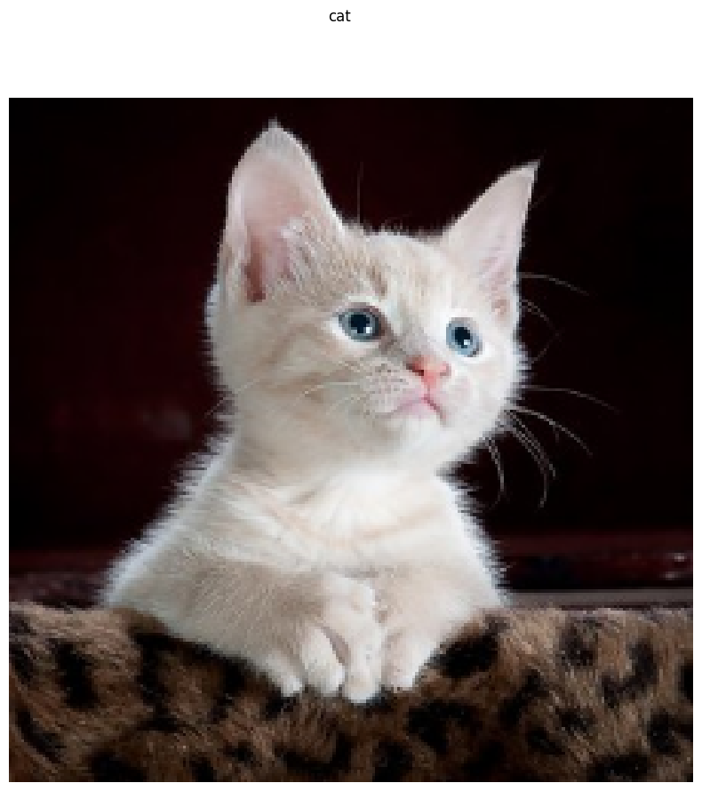

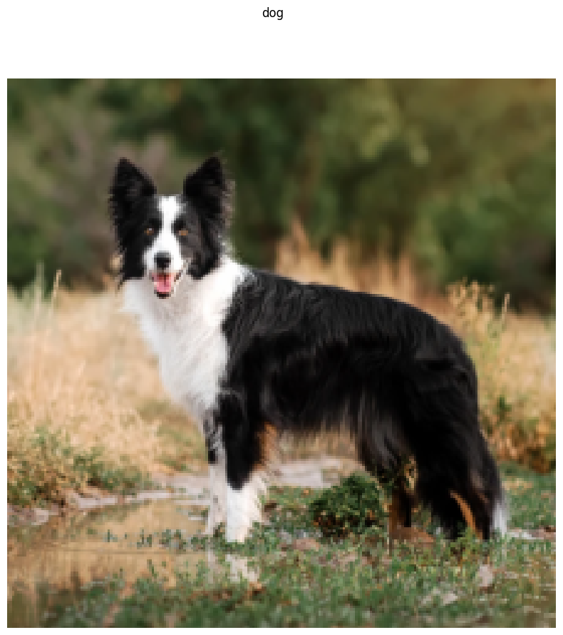

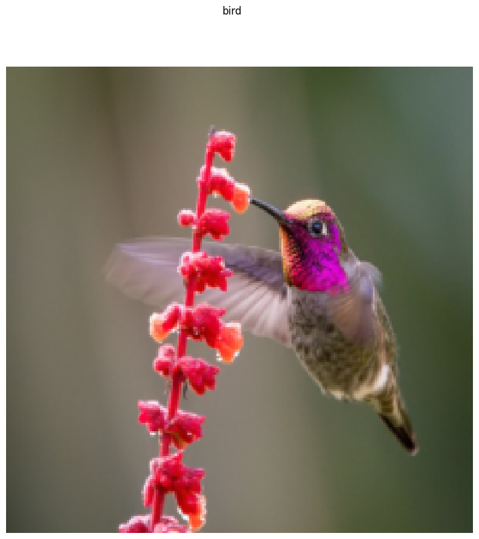

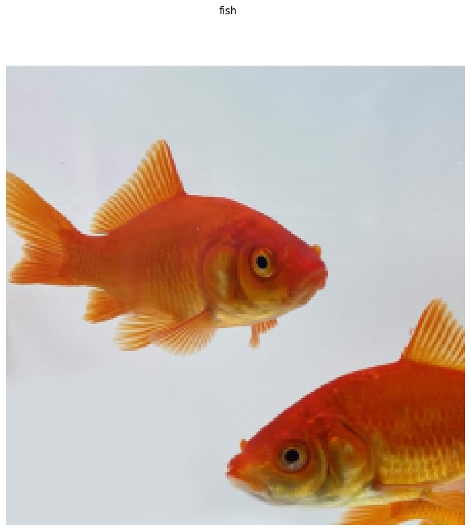

```python
import requests
import matplotlib.pyplot as plt
import numpy as np

from skimage.io import imread
from skimage.transform import resize


urls = {
    'cat': 'https://cdn.pixabay.com/photo/2014/11/30/14/11/cat-551554__340.jpg',
    'dog': ('https://static.wikia.nocookie.net/naturerules1/images/f/f9/Border-collie-1.jpg/'
            'revision/latest?cb=20210403210149'),
    'bird': 'https://static.independent.co.uk/2021/04/29/22/newFile-3.jpg?quality=75&width=1200&auto=webp',
    'fish': 'https://m.media-amazon.com/images/I/61QN8NWuNlL._AC_SX679_.jpg'
}

images = {}
original_images = {}

for key in urls:
    req = requests.get(urls[key])

    with open(f'/tmp/{key}.jpg', 'wb') as f:
        f.write(req.content)

    fig = plt.figure(figsize=(10, 10))
    fig.suptitle(key)
    img = imread(f'/tmp/{key}.jpg')
    img = resize(img, (224, 224), preserve_range=True)
    img = img.astype(np.uint8)
    original_images[key] = img
    plt.imshow(img)
    plt.gca().axis('off')
    plt.show()

    img = preprocess_input(img)
    images[key] = img
```

## 9. Vorhersagen für die vier Bilder

↑ Inhaltsverzeichnis

### Was passiert hier?

Für jedes der vier Bilder ein Vorwärtsdurchlauf und die Top-10-Klassen. Das ist der Pflicht-Sanity-Check vor jeder Erklärung: **erklärt man eine Vorhersage, die das Modell tatsächlich getroffen hat?**

### Ausgabe (Top-1 je Bild)

| Bild | Top-1-Klasse | Wahrscheinlichkeit | Top-2 |
| --- | --- | --- | --- |
| `cat` | `Egyptian_cat` | **0,570** | `tabby` (0,227) |
| `dog` | `Border_collie` | **0,863** | `collie` (0,120) |
| `bird` | `hummingbird` | **0,9999994** | `bulbul` ($3{,}8 \cdot 10^{-7}$) |
| `fish` | `goldfish` | **1,0** | `rock_beauty` ($3{,}6 \cdot 10^{-9}$) |

### Interpretation

**Alle vier sind korrekt klassifiziert** — die Vorbedingung für Teil B ist erfüllt.

Für die Heatmaps hat das eine wichtige Konsequenz: Die von LRP verteilte Gesamtrelevanz ist der **Logit** der Zielklasse. Bei Softmax 1,0 ist dieser Logit riesig, bei einer nicht gewählten Klasse kann er sogar negativ sein. **Absolute Relevanzwerte sind zwischen Bildern und Klassen nicht vergleichbar** — merken für Abschnitt 10.

### ⚠️ Ein Detail, das man leicht übersieht

Das heruntergeladene Kätzchen wird als `Egyptian_cat` (ImageNet-Index **285**) erkannt. Im nächsten Abschnitt wird es aber mit `idx=281` (`tabby`) erklärt — also mit der **zweitplatzierten** Klasse (0,227). Das ist nicht falsch, aber man muss die Heatmap entsprechend lesen: sie zeigt nicht „warum das Netz sich entschieden hat", sondern **„was für die Klasse Tabby gesprochen hätte"**. Für den Zweck dieses Abschnitts — Klassenspezifität zeigen — ist das ausreichend.

### Einordnung

Die Softmax-Werte sind hier auch ein Lehrstück über **Kalibrierung**. Eine Wahrscheinlichkeit von 1,0 heißt nicht „das Modell hat recht", sondern nur „das Modell ist sich sicher". Moderne Netze sind notorisch **überkonfident**, gerade außerhalb der Trainingsverteilung. Das ist ein weiteres Argument für XAI: Man braucht eine zweite, unabhängige Informationsquelle über die Entscheidung — und genau die liefert die Heatmap.

```python
for key in images:
    prediction = model.predict(np.expand_dims(images[key], axis=0))
    print(f'Actual class: {key}')
    print('Predictions:')
    print(decode_predictions(prediction, 10))
```

```
1/1 ━━━━━━━━━━━━━━━━━━━━ 0s 20ms/step
```

```
1/1 ━━━━━━━━━━━━━━━━━━━━ 0s 33ms/step
```

```
Actual class: cat
Predictions:
[[('n02124075', 'Egyptian_cat', np.float32(0.5703639)), ('n02123045', 'tabby', np.float32(0.22654536)), ('n02123159', 'tiger_cat', np.float32(0.07996531)), ('n02127052', 'lynx', np.float32(0.02648552)), ('n03085013', 'computer_keyboard', np.float32(0.025073044)), ('n03793489', 'mouse', np.float32(0.…
1/1 ━━━━━━━━━━━━━━━━━━━━ 0s 19ms/step
```

```
1/1 ━━━━━━━━━━━━━━━━━━━━ 0s 31ms/step
```

```
Actual class: dog
Predictions:
[[('n02106166', 'Border_collie', np.float32(0.8634703)), ('n02106030', 'collie', np.float32(0.120208345)), ('n02086910', 'papillon', np.float32(0.008836358)), ('n02105855', 'Shetland_sheepdog', np.float32(0.005663268)), ('n02105056', 'groenendael', np.float32(0.0005534191)), ('n02107683', 'Bernese_m…
1/1 ━━━━━━━━━━━━━━━━━━━━ 0s 19ms/step
```

```
1/1 ━━━━━━━━━━━━━━━━━━━━ 0s 31ms/step
```

```
Actual class: bird
Predictions:
[[('n01833805', 'hummingbird', np.float32(0.9999994)), ('n01560419', 'bulbul', np.float32(3.787509e-07)), ('n01532829', 'house_finch', np.float32(1.0395059e-07)), ('n01828970', 'bee_eater', np.float32(6.558233e-08)), ('n02028035', 'redshank', np.float32(3.3562557e-08)), ('n01534433', 'junco', np.flo…
1/1 ━━━━━━━━━━━━━━━━━━━━ 0s 19ms/step
```

```
1/1 ━━━━━━━━━━━━━━━━━━━━ 0s 32ms/step
```

```
Actual class: fish
Predictions:
```

```
[[('n01443537', 'goldfish', np.float32(1.0)), ('n02606052', 'rock_beauty', np.float32(3.5943422e-09)), ('n01440764', 'tench', np.float32(2.6454114e-10)), ('n02607072', 'anemone_fish', np.float32(7.888914e-11)), ('n09256479', 'coral_reef', np.float32(3.3217793e-11)), ('n02655020', 'puffer', np.float3…
```

## 10. Klassenspezifität: die 4×4-Matrix

↑ Inhaltsverzeichnis

### Die Frage dahinter

Der wichtigste Test für ein Erklärungsverfahren lautet: **Ändert sich die Erklärung, wenn ich nach einer anderen Klasse frage?** Eine Methode, die für jedes Ausgabeneuron dieselbe Karte malt, erklärt gar nichts — sie zeigt nur, wo im Bild „etwas ist" (eine Kantendetektion). Diese Prüfung ist der Kern der einflussreichen Arbeit *„Sanity Checks for Saliency Maps"* (Adebayo et al., 2018), an der mehrere populäre Verfahren gescheitert sind.

### Was passiert hier?

Es werden **vier Erklärer** gebaut, einer pro Zielklasse, alle mit der Composite-Strategie aus Abschnitt 7:

| Schlüssel | `idx` | ImageNet-Klasse |
| --- | --- | --- |
| `fish` | 1 | `goldfish` |
| `dog` | 232 | `Border_collie` |
| `cat` | 281 | `tabby` |
| `bird` | 94 | `hummingbird` |

`layer=25` ist dabei identisch mit `len(model.layers) - 1` aus Teil A.

Dann die Doppelschleife: **jeder Erklärer wird auf jedes Bild angewandt**, also 16 Heatmaps.

```
explanations[i][j] = explainers[keys[i]](np.expand_dims(images[keys[j]], axis=0))
#                                ↑ Zielklasse            ↑ Eingabebild
```

Das ergibt eine Matrix mit

- **Zeilen $i$** = erklärte **Klasse**,
- **Spalten $j$** = **Eingabebild**.

Auf der **Diagonale** ($i = j$) passen Klasse und Bild zusammen. Alle anderen Felder sind **kontrafaktisch**: „Was in diesem Hundebild hätte für einen Goldfisch gesprochen?"

### Wie die Abbildung aufgebaut ist

5 Zeilen × 4 Spalten. Zeile 0 zeigt die Originalfotos, Zeilen 1–4 die Heatmaps.

| Zeile | Inhalt |
| --- | --- |
| 0 | Originalbilder: Fisch, Hund, Katze, Vogel |
| 1 | Relevanz für **`goldfish`** (idx 1) |
| 2 | Relevanz für **`Border_collie`** (idx 232) |
| 3 | Relevanz für **`tabby`** (idx 281) |
| 4 | Relevanz für **`hummingbird`** (idx 94) |

Die Spaltenreihenfolge ist in allen Zeilen dieselbe: **Fisch, Hund, Katze, Vogel**.

Diese Tabelle ist nötig, weil die Zeilenbeschriftungen in der Abbildung **fehlen**: `ax[i+1][j].set_ylabel(keys[i])` wird nach `ax[i+1][j].axis('off')` aufgerufen, und mit abgeschalteter Achse zeichnet matplotlib kein Label. Ohne die Zuordnung oben ist die Abbildung schwer zu lesen.

### Was man auf der Abbildung sieht

**Die Diagonale ist durchgehend rot und klar strukturiert:**

- `goldfish` auf dem Fischbild: beide Fischkonturen rot nachgezeichnet, kräftige rote Punkte auf den Augen.
- `Border_collie` auf dem Hundebild: rote Konzentration auf **Kopf, Ohren und Gesicht** — genau die rassetypischen Merkmale.
- `tabby` auf dem Katzenbild: rote Silhouette, rote Augen, rote Ohren.
- `hummingbird` auf dem Vogelbild: rot auf Vogelkörper **und** auf der Blütenrispe.

**Die Gegendiagonale zeigt sauberes Blau:**

- Zeile 1 / Spalte Hund: Kopf und Ohren des Collies sind **kräftig blau** — Hundemerkmale sprechen aktiv **gegen** „Goldfisch".
- Zeile 2 / Spalte Fisch: spiegelbildlich, die Fischkonturen und -augen werden blau.

Dieses **antisymmetrische Paar** ist das eigentliche Ergebnis der Zelle: Dasselbe Pixel bekommt je nach gefragter Klasse das entgegengesetzte Vorzeichen. LRP ist also **klassenspezifisch** und besteht den Sanity-Check.

**Interessante Zwischenfälle abseits der Diagonale:**

- Zeile 2 / Spalte Katze: der Collie-Erklärer markiert **Ohren und Körperkontur der Katze rot**, die **Augenregion aber blau**. Fell und spitze Ohren sind gemeinsame Merkmale von Katze und Hund; die Augen sind das Unterscheidungsmerkmal. Genau dieselbe Beobachtung beschreibt das Fraunhofer-HHI-Video im Repo-Dokument.
- Zeile 3 / Spalte Hund: der Tabby-Erklärer markiert den **Rumpf des Hundes stark rot**, den **Kopf aber blau** — der behaarte Körper „könnte" eine Katze sein, der Hundekopf spricht dagegen.
- Zeile 4 / Spalte Fisch: der Kolibri-Erklärer markiert die Goldfische **kräftig rot**. Ein stromlinienförmiger Körper mit Flossen/Flügeln und warmen Farben ist für das Netz offensichtlich ein gemeinsames Merkmal. Solche **Cross-Talks** sind ein realistisches Bild dessen, wie ein CNN Klassen tatsächlich organisiert — nicht in getrennten Schubladen, sondern in geteilten Merkmalsräumen.
- Zeile 1–4 / Spalte Vogel: in allen vier Zeilen ist die **rote Blütenrispe** mitmarkiert. Sie ist das kontrastreichste Objekt im Bild und zieht in jeder Klasse Relevanz an. Ein Warnsignal-Kandidat: läge die Rispe *nur* in der Kolibri-Zeile rot, wäre das ein klarer Clever-Hans-Verdacht („Vogel = rote Blüten").

### ⚠️ Was man aus dieser Abbildung **nicht** ablesen darf

Jedes Panel wird **einzeln** normalisiert:

```
explanation = explanation / np.amax(np.abs(explanation))
```

Der Kontrast ist deshalb **zwischen den Panels nicht vergleichbar**. Ein Feld kann kräftig rot aussehen, obwohl die absolute Relevanz um Größenordnungen kleiner ist als im Nachbarfeld — bei Softmax-Werten von 1,0 bis $10^{-13}$ (Abschnitt 9) ist genau das der Fall. Wer Panels vergleichen will, muss eine **gemeinsame Skala** über alle 16 Karten verwenden.

Zweitens: die Karten für nicht vorhergesagte Klassen erklären einen **kleinen oder negativen Logit**. Sie beantworten „was spräche hypothetisch für diese Klasse", nicht „so hat das Modell entschieden".

### Einordnung

Diese Matrix ist das Werkzeug, mit dem man in der Praxis prüft, ob eine XAI-Pipeline funktioniert. Der Ablauf ist immer derselbe:

1. **Diagonale plausibel?** Zeigt die Erklärung auf das Objekt der jeweiligen Klasse?
2. **Off-Diagonale unterschiedlich?** Wenn alle 16 Karten gleich aussehen, ist die Erklärung nicht klassenspezifisch und damit wertlos.
3. **Vorzeichen sinnvoll?** Sprechen fremde Objekte gegen die Klasse (blau)?
4. **Verdächtige Hotspots?** Hintergrund, Bildränder, Wasserzeichen, Text — der Clever-Hans-Test.

Erst wenn diese vier Punkte sitzen, lohnt sich der Sprung in eine Domäne, in der man die richtige Antwort **nicht** kennt — etwa medizinische Bildgebung. Genau dort setzen die anderen Notebooks dieses Repositories an.

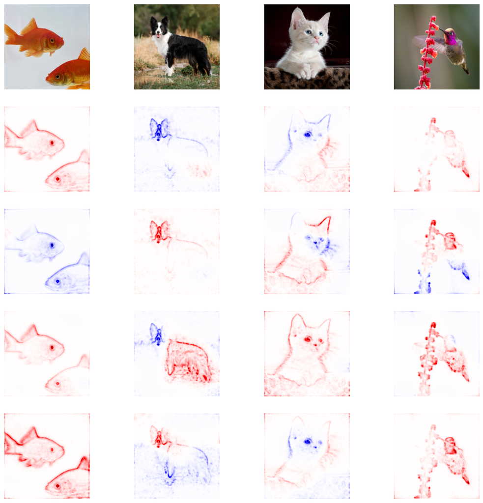

```python
from explainability import LRP

idx = [
    ('fish', 1),
    ('dog', 232),
    ('cat', 281),
    ('bird', 94)
]

explainers = {
    p[0]: LRP(model, layer=25, idx=p[1], strategy=strategy) \
    for p in idx
}

fig, ax = plt.subplots(5, 4, figsize=(15, 15))

explanations = np.zeros((4, 4), dtype=object)

keys = [p[0] for p in idx]

ax[0][0].axis('off')

for i in range(4):
    ax[0][i].imshow(original_images[keys[i]])
    ax[0][i].axis('off')

for i in range(len(keys)):
    for j in range(len(keys)):
        explanations[i][j] = explainers[keys[i]](np.expand_dims(images[keys[j]], axis=0))

for i in range(len(explanations)):
    for j in range(len(explanations[i])):
        explanation = np.sum(explanations[i][j][0], axis=-1)
        explanation = explanation / np.amax(np.abs(explanation))
        ax[i+1][j].imshow(explanation, cmap='seismic', clim=(-1, 1))
        ax[i+1][j].axis('off')
        ax[i+1][j].set_ylabel(keys[i])


plt.show()
```

## 11. Fazit und Fallstricke

↑ Inhaltsverzeichnis

### Die Regeln im Überblick

| Regel | Formel (Kern) | Charakter der Heatmap | Wofür geeignet |
| --- | --- | --- | --- |
| **LRP-0** (z-Regel) | $\dfrac{a_j w_{jk}}{\sum a w}$ | extrem rauschig, Hintergrund dominiert | Referenz/Theorie; entspricht Gradient × Input |
| **LRP-ε** | Nenner $+\,\epsilon\,\mathrm{sign}(z)$ | etwas ruhiger, gleiche Struktur | obere/dichte Schichten |
| **LRP-αβ**, α=1 β=0 | nur $(aw)^{+}$ | sauber, nur positiv, konturbetont | Präsentation; „woraus baut sich die Evidenz auf?" |
| **LRP-αβ**, α=2 β=1 | $\alpha (aw)^{+} - \beta (aw)^{-}$ | kontrastreich, mit Blau, ausreißeranfällig | Contra-Evidenz sichtbar machen |
| **flat** | $1 / \#\{j'\}$ | räumlich glatt, wertunabhängig | erste Faltungsschicht |
| **Composite** | pro Schicht die passende | scharf, fokussiert, lesbar | **Standardempfehlung** |

Nebenbedingung für αβ: $\alpha - \beta = 1$ (erzwingt die Relevanzerhaltung).

### Die sieben Punkte, die man mitnehmen sollte

1. **Es gibt nicht „die" LRP-Heatmap.** Abschnitte 3 und 7 zeigen dasselbe Modell, dasselbe Bild, dieselbe Klasse — und ein völlig anderes Ergebnis. Die Regelwahl gehört deshalb genauso dokumentiert wie die Modellarchitektur.
2. **Composite ist die Standardempfehlung**: flat unten, αβ in der Mitte, ε oben. Eine einzige Regel für das ganze Netz ist in der Regel die schlechtere Wahl.
3. **Rot heißt „pro erklärte Klasse", blau „contra".** Immer relativ zur gewählten Klasse — dasselbe Pixel kann in beiden Farben erscheinen (Abschnitt 10).
4. **Normalisierung ist Teil der Methode, nicht Kosmetik.** Ein leeres Panel bedeutet meist einen Skalierungsfehler (Abschnitt 5), und Max-Normalisierung kann von drei Pixeln zerstört werden (Abschnitt 6). Perzentil-basiertes Clipping ist robuster.
5. **Absolutwerte sind nicht vergleichbar** — nicht zwischen Regeln, nicht zwischen Bildern, nicht zwischen Klassen, und bei panelweiser Normalisierung auch nicht innerhalb einer Abbildung.
6. **Artefakte kennen und benennen**: blaue Ränder durch Padding (Abschnitt 7), Rastermuster durch *winner-takes-all*-Pooling, Relevanz-Leck durch Bias-Terme (Abschnitt 6). Nicht jede Struktur in einer Heatmap ist ein Befund über das Modell.
7. **Gegen eine Referenz validieren.** Der Vergleich mit iNNvestigate ist der eigentliche Existenzgrund von Teil A. Ein XAI-Verfahren liefert immer ein plausibel aussehendes Bild — auch wenn es falsch implementiert ist.

### Wie es weitergeht

Dieses Notebook ist der kontrollierte Laborfall: bekanntes Modell, bekannte Klassen, bekannte Referenzwerte. Die anderen Notebooks dieses Repositories wenden dieselben Regeln auf Fälle an, in denen die richtige Antwort **nicht** bekannt ist:

| Notebook | Aufgabe |
| --- | --- |
| `Train_and_explain_dummy_geometric_data` | synthetische Formen mit bekannter Ground Truth — der Test, ob LRP die *tatsächlich* eingebaute Ursache findet |
| `Train_and_explain_3D_mnist_model` | Übergang von 2D zu 3D-Volumendaten |
| `Train_and_explain_synthetic_brain_regression_model` | Regression statt Klassifikation, auf synthetischen Hirnbildern |
| `Explain_brain_age_predictions` | der echte Anwendungsfall: Brain Age auf MRT-Daten, mit Auswertung pro Hirnregion |

Wer LRP über dieses Repository hinaus verwenden will: [**Zennit**](https://github.com/chr5tphr/zennit) (PyTorch), [**iNNvestigate**](https://github.com/albermax/innvestigate) (Keras/TensorFlow) und **LXT** (LRP für Transformer). Die interaktive Demo unter [lrpserver.hhi.fraunhofer.de](https://lrpserver.hhi.fraunhofer.de/) erlaubt es, die Regelparameter im Browser zu verschieben und den Effekt sofort zu sehen.